# PSTAT 131 HW 3

Jay Shreedhar

2022-04-20

```r
titanic <- read.csv(file='data/titanic.csv')
titanic$survived <- factor(titanic$survived, levels=c("Yes", "No"))
titanic$pclass <- factor(titanic$pclass)
```

**Question 1:**

```r
titanic_split <- initial_split(titanic, prop=0.8, strata=survived)
titanic_train <- training(titanic_split)
titanic_test <- testing(titanic_split)
```

Yes, the datasets have the right number of observations. There are a lot of missing cabin numbers and a few missing ages. Stratifying by `survived` ensures that we are not creating datasets that are biased toward or against passengers who survived.  
**Question 2:**

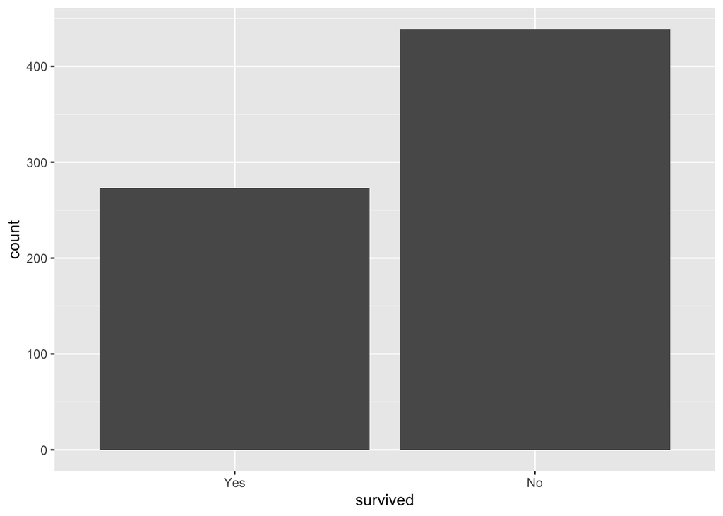

```r
titanic_train %>%
  ggplot(aes(x=survived)) +
  geom_bar()
```

```r
dat <- titanic_train %>%
          select(where(is.numeric)) %>%
  correlate()
```

```
##
## Correlation method: 'pearson'
## Missing treated using: 'pairwise.complete.obs'
```

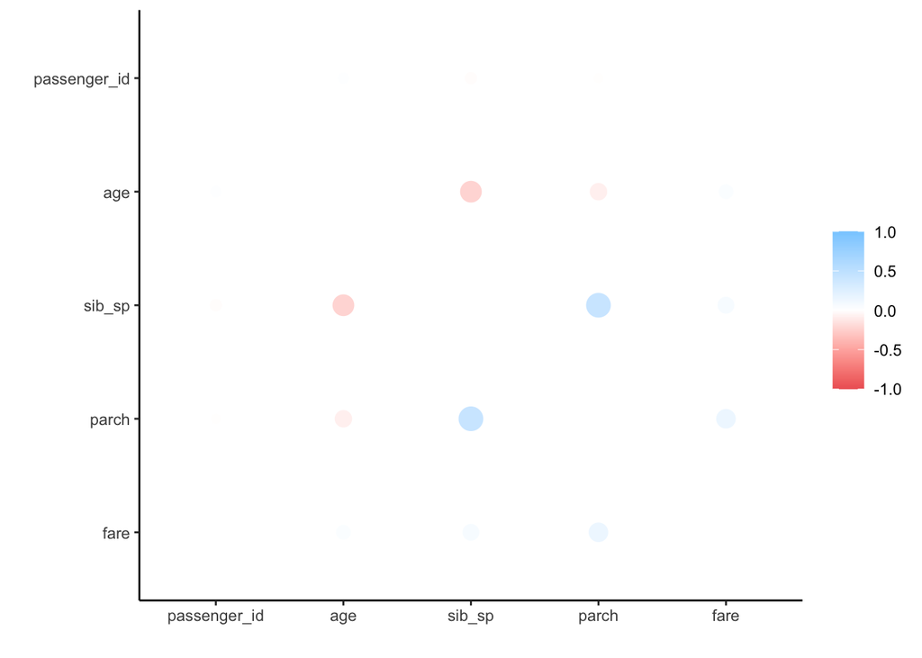

```r
rplot(dat)
```

It seems that `parch` and `sib_sp` are positively correlated, and `age` and `sib_sp` are negatively correlated. There are also faint positive correlations between `fare` and `parch`, `sib_sp`, and `age`, and a faint negative correlation between `parch` and `age.`  
**Question 4:**

```r
titanic_recipe <-
  recipe(survived ~ pclass + sex + age + sib_sp + parch + fare, data=titanic_train) %>% step_impute_linear(age) %>%
  step_dummy(all_nominal_predictors()) %>%
  step_interact(terms = ~ starts_with("sex"):fare) %>%
  step_interact(terms = ~ age:fare)
```

**Question 5:**

```r
log_reg <- logistic_reg() %>%
  set_engine("glm") %>%
  set_mode("classification")

log_wkflow <- workflow() %>%
  add_model(log_reg) %>%
  add_recipe(titanic_recipe)

log_fit <- fit(log_wkflow, titanic_train)
```

**Question 6:**

```r
lindisc <- discrim_linear() %>%
  set_engine("MASS") %>%
  set_mode("classification")

lin_wkflow <- workflow() %>%
  add_model(lindisc) %>%
  add_recipe(titanic_recipe)

lin_fit <- fit(lin_wkflow, titanic_train)
```

**Question 7:**

```r
quadisc <- discrim_quad() %>%
  set_engine("MASS") %>%
  set_mode("classification")

quad_wkflow <- workflow() %>%
  add_model(quadisc) %>%
  add_recipe(titanic_recipe)

quad_fit <- fit(quad_wkflow, titanic_train)
```

**Question 8:**

```r
nbmod <- naive_Bayes() %>%
  set_engine("klaR") %>%
  set_mode("classification") %>%
  set_args(usekernel=FALSE)

nb_wkflow <- workflow() %>%
  add_model(nbmod) %>%
  add_recipe(titanic_recipe)

nb_fit <- fit(nb_wkflow, titanic_train)
```

**Question 9:**

```r
logisticmod <- predict(log_fit, new_data = titanic_train, type = "prob")
logisticcol <- bind_cols(logisticmod, titanic_train)
logisticacc <- augment(log_fit, new_data = titanic_train) %>%
  accuracy(truth = survived, estimate = .pred_class)
lineardiscrimmod <- predict(lin_fit, new_data = titanic_train, type = "prob")
lindisccol <- bind_cols(lineardiscrimmod, titanic_train)
linacc <- augment(lin_fit, new_data = titanic_train) %>%
  accuracy(truth = survived, estimate = .pred_class)
quaddiscrimmod <- predict(quad_fit, new_data = titanic_train, type = "prob")
quadisccol <- bind_cols(quaddiscrimmod, titanic_train)
quadacc <- augment(quad_fit, new_data = titanic_train) %>%
  accuracy(truth = survived, estimate = .pred_class)
naivebayesmod <- predict(nb_fit, new_data = titanic_train, type = "prob")
nbcol <- bind_cols(naivebayesmod, titanic_train)
bayesacc <- augment(nb_fit, new_data = titanic_train) %>%
  accuracy(truth = survived, estimate = .pred_class)

accuracies <- c(logisticacc$.estimate, linacc$.estimate,
                quadacc$.estimate, bayesacc$.estimate)
models <- c("Logistic Regression", "Linear Discriminant", "Naive Bayes", "Quadratic Discriminant")
results <- tibble(accuracies = accuracies, models = models)
results %>%
  arrange(-accuracies)
```

```
## # A tibble: 4 × 2
##   accuracies models
##        <dbl> <chr>
## 1      0.816 Logistic Regression
## 2      0.805 Linear Discriminant
## 3      0.778 Quadratic Discriminant
## 4      0.777 Naive Bayes
```

Logistic regression achieved the highest accuracy of 0.8160112.  
**Question 10:** Accuracy:

```r
testfit <- predict(log_fit, new_data = titanic_test, type = "prob")
augment(log_fit, new_data = titanic_test) %>%
  accuracy(truth = survived, estimate = .pred_class)
```

```
## # A tibble: 1 × 3
##   .metric  .estimator .estimate
##   <chr>    <chr>          <dbl>
## 1 accuracy binary         0.799
```

Confusion matrix:

```r
augment(log_fit, new_data = titanic_test) %>%
  conf_mat(truth = survived, estimate = .pred_class)
```

```
##           Truth
## Prediction Yes No
##        Yes  46 13
##        No   23 97
```

ROC curve:

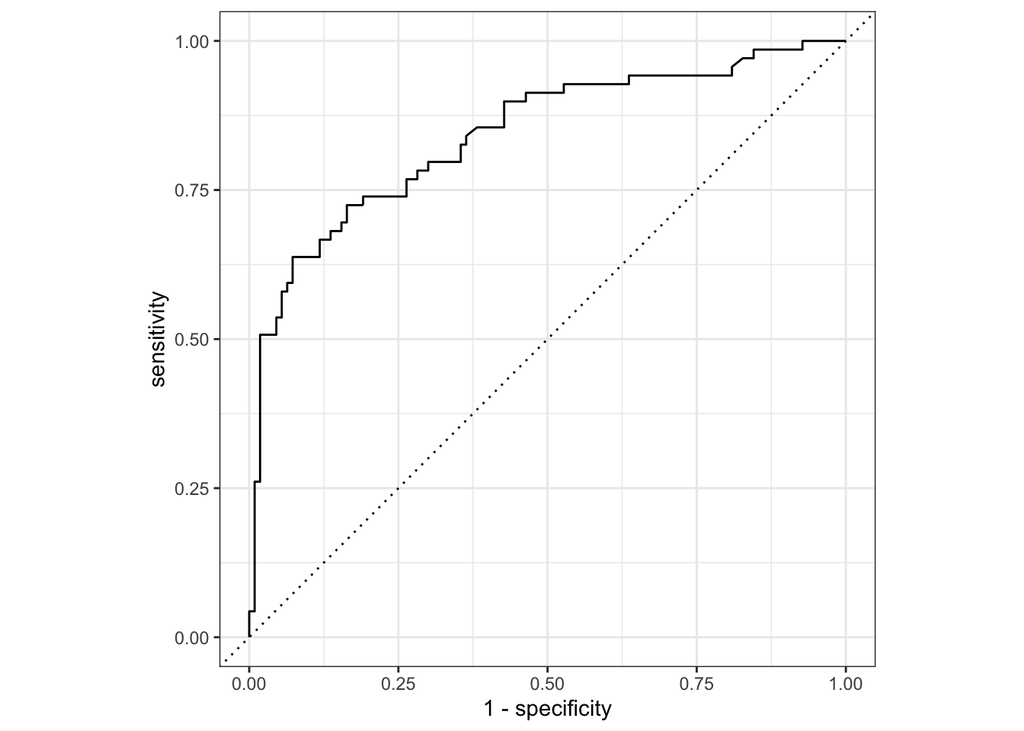

```r
augment(log_fit, new_data = titanic_test) %>%
  roc_curve(survived, .pred_Yes) %>%
  autoplot()
```

```r
augment(log_fit, new_data = titanic_test) %>%
  roc_auc(survived, .pred_Yes)
```

```
## # A tibble: 1 × 3
##   .metric .estimator .estimate
##   <chr>   <chr>          <dbl>
## 1 roc_auc binary         0.842
```

The AUC is estimated to be 0.8421607.  
The accuracy for the testing data was 0.7988827, so pretty close to what it was for the training data. However, it is still lower. This is probably due to slight overfitting.